# BANK MARKETING DATASET ANALYSIS

Author: Ioannis Frangistas (Copyrighted Material - All copyrights reserved)

## Overview & Scope

### Business Problem

A bank conducts telephone sales campaigns aimed at convincing customers to open a **term deposit**. This analysis seeks to:

- Accurately predict which customers are likely to respond positively.
- Understand the most important factors influencing that decision.
- Optimize the targeting of future campaigns by reducing call costs.

### Analytical Objectives

1. **Data Cleaning & Preprocessing** — Clean raw data, handle missing values, apply outlier capping and one-hot encoding.
2. **EDA** — Analyze distributions, class imbalance, and relationships between variables.
3. **Model Training & Comparison** — Train and compare Logistic Regression, Random Forest, and XGBoost.
4. **Model Selection** — Select the best model based on ROC AUC, Average Precision, and F1.
5. **Explainability** — Interpret results using Feature Importances and SHAP values.

## Dataset Description

| Attribute | Value |
| --- | --- |
| **Source** | UCI Bank Marketing — `bank-additional-full.csv` |
| **Original size** | 41,188 records × 21 columns |
| **After cleaning** | 41,170 records × 20 columns |
| **Target** | `deposit` (1 = yes, 0 = no) |
| **Class distribution** | ~89% No (36,548) / ~11% Yes (4,640) |

### Feature Groups

- **Demographic:** `age`, `job`, `marital`, `education`
- **Financial:** `housing`, `loan`
- **Campaign:** `contact`, `month`, `day_of_week`, `duration`, `campaign`, `previous`, `poutcome`, `prev_contact` (engineered feature)
- **Macroeconomic indicators:** `emp.var.rate`, `cons.price.idx`, `cons.conf.idx`, `euribor3m`, `nr.employed`

## Executive Summary

### Key EDA Findings

- **Strong class imbalance:** Only ~11% of customers subscribe to a term deposit, requiring `class_weight='balanced'` and evaluation metrics beyond simple accuracy.
- **Call duration (`duration`):** An extremely powerful predictor — longer calls are strongly associated with positive responses, though this variable is only known after the call takes place.
- **Macroeconomic context:** `euribor3m` and `cons.price.idx` significantly influence subscription probability — periods of lower interest rates tend to favor deposits.
- **Timing:** May calls show a negative effect, while October and March are associated with higher conversion rates.
- **Previous contact outcome (`poutcome_success`):** Customers with a successful response in a prior campaign are far more likely to subscribe again.

### Modeling Results

| Model | ROC AUC | Avg Precision | Best F1 | Best Threshold |
| --- | --- | --- | --- | --- |
| **XGBoost** 🏆 | **0.946** | **0.649** | **0.643** | 0.74 |
| Random Forest | 0.941 | 0.630 | 0.626 | 0.66 |
| Logistic Regression | 0.935 | 0.577 | 0.616 | 0.65 |

**Best model: XGBoost** with ROC AUC = 0.946 and Average Precision = 0.649 on the test set (70/30 stratified split).

### Top 5 Most Important Features (SHAP — XGBoost)

[output not shown]

### Conclusion

XGBoost achieves **ROC AUC ≈ 0.95** — excellent performance for highly imbalanced marketing data. SHAP analysis shows that call duration and macroeconomic conditions dominate the predictions. Campaign timing (avoiding May, focusing on October/March) and leveraging customer history (`poutcome_success`) can significantly improve the effectiveness of the next campaign.

## 1. Data Loading & Full Preprocessing / Cleaning

We start from the original raw file `bank-additional-full.csv` and produce two processed datasets:

- `bank_additional_clean_minimal.csv`: cleaned, still with categorical variables (for EDA).
- `bank_additional_model_ready.csv`: fully numeric (one‑hot encoded) dataset for modeling.

```python
import numpy as np
import pandas as pd

# Load raw dataset
df = pd.read_csv("data/raw/bank-additional-full.csv", sep=";")
df.head()
```

|  | age | job | marital | education | default | housing | loan | contact | month | day_of_week | ... | campaign | pdays | previous | poutcome | emp.var.rate | cons.price.idx | cons.conf.idx | euribor3m | nr.employed | y |
| --- | --- | --- | --- | --- | --- | --- | --- | --- | --- | --- | --- | --- | --- | --- | --- | --- | --- | --- | --- | --- | --- |
| 0 | 56 | housemaid | married | basic.4y | no | no | no | telephone | may | mon | ... | 1 | 999 | 0 | nonexistent | 1.1 | 93.994 | -36.4 | 4.857 | 5191.0 | no |
| 1 | 57 | services | married | high.school | unknown | no | no | telephone | may | mon | ... | 1 | 999 | 0 | nonexistent | 1.1 | 93.994 | -36.4 | 4.857 | 5191.0 | no |
| 2 | 37 | services | married | high.school | no | yes | no | telephone | may | mon | ... | 1 | 999 | 0 | nonexistent | 1.1 | 93.994 | -36.4 | 4.857 | 5191.0 | no |
| 3 | 40 | admin. | married | basic.6y | no | no | no | telephone | may | mon | ... | 1 | 999 | 0 | nonexistent | 1.1 | 93.994 | -36.4 | 4.857 | 5191.0 | no |
| 4 | 56 | services | married | high.school | no | no | yes | telephone | may | mon | ... | 1 | 999 | 0 | nonexistent | 1.1 | 93.994 | -36.4 | 4.857 | 5191.0 | no |

5 rows × 21 columns

```python
# Initial structure overview
df.info()
```

```
<class 'pandas.DataFrame'>
RangeIndex: 41188 entries, 0 to 41187
Data columns (total 21 columns):
 #   Column          Non-Null Count  Dtype
---  ------          --------------  -----
 0   age             41188 non-null  int64
 1   job             41188 non-null  str
 2   marital         41188 non-null  str
 3   education       41188 non-null  str
 4   default         41188 non-null  str
 5   housing         41188 non-null  str
 6   loan            41188 non-null  str
 7   contact         41188 non-null  str
 8   month           41188 non-null  str
 9   day_of_week     41188 non-null  str
 10  duration        41188 non-null  int64
 11  campaign        41188 non-null  int64
 12  pdays           41188 non-null  int64
 13  previous        41188 non-null  int64
 14  poutcome        41188 non-null  str
 15  emp.var.rate    41188 non-null  float64
 16  cons.price.idx  41188 non-null  float64
 17  cons.conf.idx   41188 non-null  float64
 18  euribor3m       41188 non-null  float64
 19  nr.employed     41188 non-null  float64
 20  y               41188 non-null  str
dtypes: float64(5), int64(5), str(11)
memory usage: 9.1 MB
```

```python
# Standardize column names and trim string values
df.columns = [c.strip().lower() for c in df.columns]
str_cols = df.select_dtypes(include="object").columns
df[str_cols] = df[str_cols].apply(lambda s: s.str.strip())
```

```python
# The original target is column 'y' (yes/no). Create numeric 'deposit' and drop 'y'.
df["deposit"] = df["y"].map({"yes": 1, "no": 0}).astype("int8")
df = df.drop(columns=["y"])

df["deposit"].value_counts(dropna=False)
```

```
deposit
0    36548
1     4640
Name: count, dtype: int64
```

The target is strongly imbalanced: the "no deposit" class dominates, so we will later use techniques like `class_weight='balanced'` or other imbalance‑aware strategies during modeling.[file:6]

```python
# Replace 'unknown' with NaN in all categorical variables
cat_cols = df.select_dtypes(include="object").columns.tolist()
df[cat_cols] = df[cat_cols].replace("unknown", np.nan)
```

```python
# Handle previous campaign variables: pdays, previous, poutcome

# pdays: 999 or -1 means "no previous contact". We create a flag 'prev_contact'
never_contact = (df["pdays"] == 999) | (df["pdays"] == -1)
df["prev_contact"] = (~never_contact).astype("int8")
```

```python
# Set pdays to NaN where there was no previous contact
df.loc[never_contact, "pdays"] = np.nan

# Ensure consistency for previous and poutcome when there was no previous contact
df.loc[df["prev_contact"] == 0, "previous"] = 0
df.loc[df["prev_contact"] == 0, "poutcome"] = np.nan
```

```python
# Remove problematic pdays column
df.drop(columns=["pdays"], inplace=True)
```

```python
# Education categories: group multiple "basic.*" levels into a single "basic"
if "education" in df.columns:
    df["education"] = df["education"].replace(
        {"basic.4y": "basic", "basic.6y": "basic", "basic.9y": "basic"}
    )

df["education"].value_counts(dropna=False)
```

```
education
basic                  12513
university.degree      12168
high.school             9515
professional.course     5243
NaN                     1731
illiterate                18
Name: count, dtype: int64
```

```python
# Inspect 'default' – it is mostly missing or "no"
df["default"].value_counts(dropna=False)
```

```
default
no     32588
NaN     8597
yes        3
Name: count, dtype: int64
```

```python
# Drop 'default', as its information content is very poor and inconsistent
df = df.drop(columns=["default"])
```

```python
# Remove duplicate rows (if any)
df = df.drop_duplicates().reset_index(drop=True)
df.shape
```

```
(41170, 20)
```

```python
# Identify variables with extreme values (outliers)
cols_to_check = ["campaign", "previous", "age"]
print(df[cols_to_check].describe(percentiles=[0.01, 0.05, 0.5, 0.95, 0.99]).round(2))
```

```
       campaign  previous       age
count  41170.00  41170.00  41170.00
mean       2.57      0.06     40.02
std        2.77      0.36     10.42
min        1.00      0.00     17.00
1%         1.00      0.00     23.00
5%         1.00      0.00     26.00
50%        2.00      0.00     38.00
95%        7.00      0.00     58.00
99%       14.00      2.00     71.00
max       56.00      7.00     98.00
```

```python
# Apply capping of extreme values at the 1st and 99th percentiles
for col in ["campaign", "previous", "age"]:
    lo, hi = df[col].quantile([0.01, 0.99])
    df[col] = df[col].clip(lo, hi)

print(df[cols_to_check].describe(percentiles=[0.01, 0.05, 0.5, 0.95, 0.99]).round(2))
```

```
       campaign  previous       age
count   41170.0  41170.00  41170.00
mean        2.5      0.05     39.98
std         2.3      0.29     10.14
min         1.0      0.00     23.00
1%          1.0      0.00     23.00
5%          1.0      0.00     26.00
50%         2.0      0.00     38.00
95%         7.0      0.00     58.00
99%        14.0      2.00     71.00
max        14.0      2.00     71.00
```

```python
# Save cleaned dataset for EDA (still with categorical variables)
df.to_csv("data/processed/bank_additional_clean_minimal.csv", index=False)

# One‑hot encode all categorical variables for modeling
df_model = pd.get_dummies(df, dummy_na=True, drop_first=True)

# Save fully numeric dataset for modeling
df_model.to_csv("data/processed/bank_additional_model_ready.csv", index=False)
```

The file `bank_additional_clean_minimal.csv` will be used for EDA, while `bank_additional_model_ready.csv` will feed the modeling section.

## 2. Exploratory Data Analysis (EDA)

We now perform descriptive analysis on the cleaned dataset `bank_additional_clean_minimal.csv`:

- Basic descriptive statistics for numeric variables.
- Target distribution (class imbalance).
- Selected univariate and bivariate plots.

```python
import matplotlib.pyplot as plt
import seaborn as sns

plt.style.use("seaborn-v0_8-whitegrid")

eda_df = pd.read_csv("data/processed/bank_additional_clean_minimal.csv")
eda_df.head()
```

|  | age | job | marital | education | housing | loan | contact | month | day_of_week | duration | campaign | previous | poutcome | emp.var.rate | cons.price.idx | cons.conf.idx | euribor3m | nr.employed | deposit | prev_contact |
| --- | --- | --- | --- | --- | --- | --- | --- | --- | --- | --- | --- | --- | --- | --- | --- | --- | --- | --- | --- | --- |
| 0 | 56 | housemaid | married | basic | no | no | telephone | may | mon | 261 | 1 | 0 | NaN | 1.1 | 93.994 | -36.4 | 4.857 | 5191.0 | 0 | 0 |
| 1 | 57 | services | married | high.school | no | no | telephone | may | mon | 149 | 1 | 0 | NaN | 1.1 | 93.994 | -36.4 | 4.857 | 5191.0 | 0 | 0 |
| 2 | 37 | services | married | high.school | yes | no | telephone | may | mon | 226 | 1 | 0 | NaN | 1.1 | 93.994 | -36.4 | 4.857 | 5191.0 | 0 | 0 |
| 3 | 40 | admin. | married | basic | no | no | telephone | may | mon | 151 | 1 | 0 | NaN | 1.1 | 93.994 | -36.4 | 4.857 | 5191.0 | 0 | 0 |
| 4 | 56 | services | married | high.school | no | yes | telephone | may | mon | 307 | 1 | 0 | NaN | 1.1 | 93.994 | -36.4 | 4.857 | 5191.0 | 0 | 0 |

```python
# Basic numeric summary
eda_df.describe().round(2)
```

|  | age | duration | campaign | previous | emp.var.rate | cons.price.idx | cons.conf.idx | euribor3m | nr.employed | deposit | prev_contact |
| --- | --- | --- | --- | --- | --- | --- | --- | --- | --- | --- | --- |
| count | 41170.00 | 41170.00 | 41170.0 | 41170.00 | 41170.00 | 41170.00 | 41170.00 | 41170.00 | 41170.00 | 41170.00 | 41170.00 |
| mean | 39.98 | 258.33 | 2.5 | 0.05 | 0.08 | 93.58 | -40.50 | 3.62 | 5167.04 | 0.11 | 0.04 |
| std | 10.14 | 259.32 | 2.3 | 0.29 | 1.57 | 0.58 | 4.63 | 1.73 | 72.25 | 0.32 | 0.19 |
| min | 23.00 | 0.00 | 1.0 | 0.00 | -3.40 | 92.20 | -50.80 | 0.63 | 4963.60 | 0.00 | 0.00 |
| 25% | 32.00 | 102.00 | 1.0 | 0.00 | -1.80 | 93.08 | -42.70 | 1.34 | 5099.10 | 0.00 | 0.00 |
| 50% | 38.00 | 180.00 | 2.0 | 0.00 | 1.10 | 93.75 | -41.80 | 4.86 | 5191.00 | 0.00 | 0.00 |
| 75% | 47.00 | 319.00 | 3.0 | 0.00 | 1.40 | 93.99 | -36.40 | 4.96 | 5228.10 | 0.00 | 0.00 |
| max | 71.00 | 4918.00 | 14.0 | 2.00 | 1.40 | 94.77 | -26.90 | 5.04 | 5228.10 | 1.00 | 1.00 |

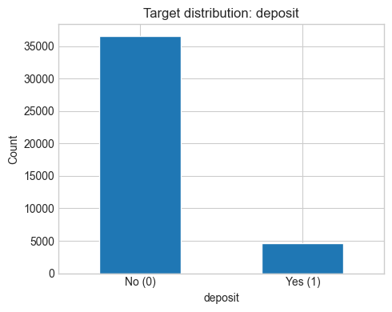

```python
# Target distribution
fig, ax = plt.subplots(figsize=(5, 4))
eda_df["deposit"].value_counts().sort_index().plot(kind="bar", ax=ax)
ax.set_xticklabels(["No (0)", "Yes (1)"], rotation=0)
ax.set_ylabel("Count")
ax.set_title("Target distribution: deposit")
plt.tight_layout()
plt.show()
```

- The negative class (no deposit) is much more frequent than the positive class (deposit), so accuracy alone would be misleading. We will focus on ROC AUC, Average Precision, and F1.

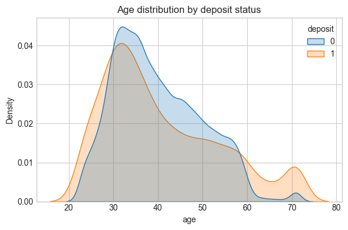

```python
# Distribution of age by deposit status
fig, ax = plt.subplots(figsize=(6, 4))
sns.kdeplot(
    data=eda_df,
    x="age",
    hue="deposit",
    fill=True,
    common_norm=False,
    ax=ax,
)
ax.set_title("Age distribution by deposit status")
plt.tight_layout()
plt.show()
```

- Customers who did subscribe (`deposit=1`) tend to be slightly older than those who did not, although the distributions overlap substantially.

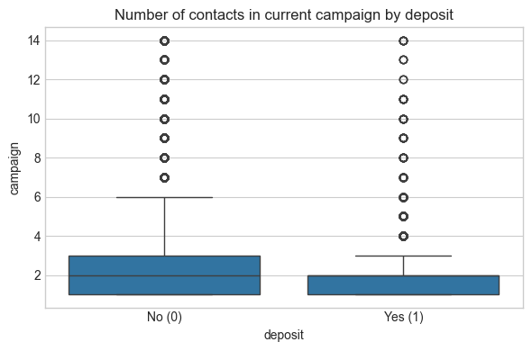

```python
# Campaign intensity vs deposit
fig, ax = plt.subplots(figsize=(6, 4))
sns.boxplot(data=eda_df, x="deposit", y="campaign", ax=ax)

ax.set_xticks([0, 1])
ax.set_xticklabels(["No (0)", "Yes (1)"])

ax.set_title("Number of contacts in current campaign by deposit")
plt.tight_layout()
plt.show()
```

- Most customers were contacted only a few times during the current campaign, with a long tail towards higher values that we have already capped in the cleaning stage

```python
# Previous contact flag vs deposit
pd.crosstab(eda_df["prev_contact"], eda_df["deposit"], normalize="index").round(3)
```

| deposit prev_contact | 0 | 1 |
| --- | --- | --- |
| 0 | 0.907 | 0.093 |
| 1 | 0.362 | 0.638 |

- Only about 4% of customers had a previous contact (`prev_contact=1`), but when previous contact exists, the probability of subscribing is noticeably higher, suggesting that recency / prior history is a strong driver of response.

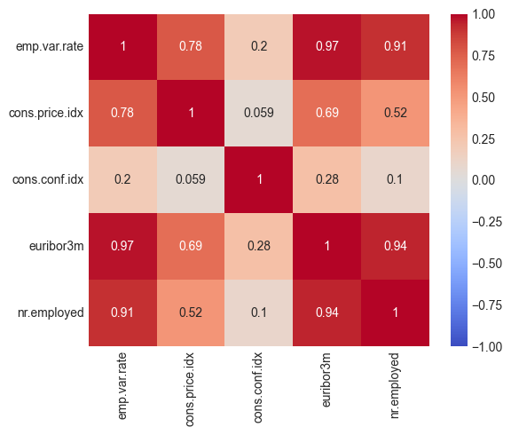

```python
# Check macro‑economic variable correlations in the EDA dataset
macro_cols_eda = [
    c for c in ["emp.var.rate", "cons.price.idx", "cons.conf.idx", "euribor3m", "nr.employed"]
    if c in eda_df.columns
]

if macro_cols_eda:
    corr_macro = eda_df[macro_cols_eda].corr().round(3)
    plt.figure(figsize=(6, 5))
    sns.heatmap(corr_macro, annot=True, cmap="coolwarm", vmin=-1, vmax=1)
    ax.set_title("Correlation of macro-economic variables")
    plt.tight_layout()
    plt.show()
```

- Macro‑economic indicators are strongly correlated (e.g. `emp.var.rate` with `euribor3m` and `nr.employed`), so we avoid including all of them simultaneously in linear models to reduce multicollinearity.

## 3. Modeling

Goals of the modeling section:

1. Train multiple models on the fully numeric dataset:
   - Logistic Regression
   - Random Forest
   - XGBoost
2. Evaluate them using metrics suited to imbalanced classification:
   - ROC AUC
   - Average Precision (PR‑AUC)
   - F1 score at the best decision threshold.
3. Select the best performing model.
4. Interpret the chosen model using feature importances and SHAP values.

```python
import matplotlib.pyplot as plt
import numpy as np
import pandas as pd

from sklearn.model_selection import train_test_split
from sklearn.preprocessing import StandardScaler

from sklearn.metrics import (
    roc_auc_score,
    average_precision_score,
    f1_score,
)

from sklearn.linear_model import LogisticRegression
from sklearn.ensemble import RandomForestClassifier
from xgboost import XGBClassifier

import shap

# Load model‑ready dataset
model_df = pd.read_csv("data/processed/bank_additional_model_ready.csv")

y = model_df["deposit"].astype(int).values
X = model_df.drop(columns=["deposit"])
feature_names = X.columns.tolist()
```

```python
# Select macro‑economic columns that exist
macro_all = ["emp.var.rate", "cons.price.idx", "cons.conf.idx", "euribor3m", "nr.employed"]
macro_cols = [c for c in macro_all if c in X.columns]
macro_cols
```

```
['emp.var.rate', 'cons.price.idx', 'cons.conf.idx', 'euribor3m', 'nr.employed']
```

```python
# Correlation among macro‑economic variables (sanity check)
if macro_cols:
    corr_macro_model = X[macro_cols].corr().round(3)
    corr_macro_model

# Keep a subset of macro variables to reduce multicollinearity
keep_macro = [c for c in ["euribor3m", "cons.conf.idx", "cons.price.idx"] if c in macro_cols]
drop_macro = [c for c in macro_cols if c not in keep_macro]
X = X.drop(columns=drop_macro, errors="ignore")
feature_names = X.columns.tolist()
```

```python
# Train / test split with stratification on the target
X_train, X_test, y_train, y_test = train_test_split(
    X, y, test_size=0.30, stratify=y, random_state=42
)

print(f"Train: {X_train.shape}, Test: {X_test.shape}, PosRate(train)={y_train.mean():.2f}")
```

```
Train: (28819, 50), Test: (12351, 50), PosRate(train)=0.11
```

### 3.1 Define models and evaluation helper

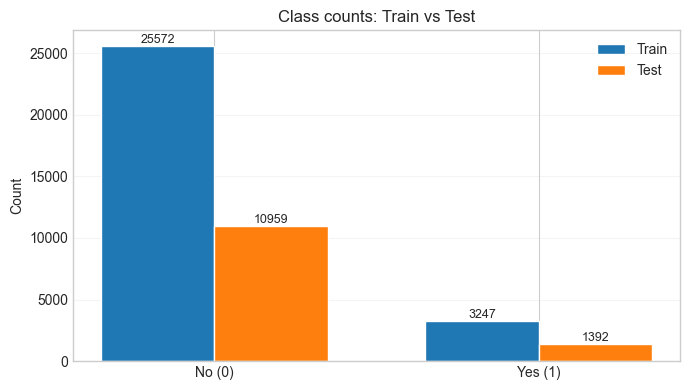

```python
# Helper: count class instances
def class_counts(y_vec):
    unique, cnt = np.unique(y_vec, return_counts=True)
    d = {int(k): int(v) for k, v in zip(unique, cnt)}
    return d.get(0, 0), d.get(1, 0)

train_no, train_yes = class_counts(y_train)
test_no, test_yes = class_counts(y_test)

labels = ["No (0)", "Yes (1)"]
train_vals = [train_no, train_yes]
test_vals = [test_no, test_yes]

x_pos = np.arange(len(labels))
w = 0.35

fig, ax = plt.subplots(figsize=(7, 4))
rects1 = ax.bar(x_pos - w / 2, train_vals, width=w, label="Train")
rects2 = ax.bar(x_pos + w / 2, test_vals, width=w, label="Test")

ax.set_xticks(x_pos)
ax.set_xticklabels(labels)
ax.set_ylabel("Count")
ax.set_title("Class counts: Train vs Test")
ax.legend()
ax.grid(axis="y", alpha=0.2)

for rects in (rects1, rects2):
    for r in rects:
        height = r.get_height()
        ax.text(r.get_x() + r.get_width() / 2, height, f"{height}", ha="center", va="bottom", fontsize=9)

plt.tight_layout()
plt.show()
```

```python
## Models

# Scale features for Logistic Regression (not required for tree‑based models)
scaler = StandardScaler(with_mean=False)
X_train_scaled = scaler.fit_transform(X_train)
X_test_scaled = scaler.transform(X_test)

# Logistic Regression with class_weight='balanced'
log_reg = LogisticRegression(
    max_iter=500,
    class_weight="balanced",
    solver="liblinear"
)

# Random Forest classifier
rf_clf = RandomForestClassifier(
    n_estimators=300,
    max_depth=None,
    min_samples_leaf=50,
    class_weight="balanced",
    random_state=42,
    n_jobs=-1,
)

# XGBoost classifier with scale_pos_weight for imbalance
pos_weight = (len(y_train) - y_train.sum()) / y_train.sum()
xgb_clf = XGBClassifier(
    n_estimators=400,
    learning_rate=0.05,
    max_depth=4,
    subsample=0.8,
    colsample_bytree=0.8,
    objective="binary:logistic",
    scale_pos_weight=pos_weight,
    eval_metric="logloss",
    random_state=42,
    n_jobs=-1,
)

def evaluate_model(name, model, X_train_in, X_test_in, y_train_in, y_test_in):

# Model Fit
    model.fit(X_train_in, y_train_in)
    y_proba = model.predict_proba(X_test_in)[:, 1]

    roc_auc = roc_auc_score(y_test_in, y_proba)
    ap = average_precision_score(y_test_in, y_proba)

    thresholds = np.linspace(0.1, 0.9, 81)
    f1_scores = []
    for t in thresholds:
        y_pred = (y_proba >= t).astype(int)
        f1_scores.append(f1_score(y_test_in, y_pred))

    best_idx = int(np.argmax(f1_scores))
    best_t = thresholds[best_idx]
    best_f1 = f1_scores[best_idx]

    return {
        "name": name,
        "model": model,
        "roc_auc": roc_auc,
        "avg_precision": ap,
        "best_threshold": best_t,
        "best_f1": best_f1,
        "y_proba": y_proba,
    }
```

### 3.2 Train and compare Logistic Regression, Random Forest, and XGBoost

```python
results = []

# Logistic Regression (uses scaled features)
res_log = evaluate_model(
    "Logistic Regression",
    log_reg,
    X_train_scaled,
    X_test_scaled,
    y_train,
    y_test,
)
results.append(res_log)

# Random Forest (raw features)
res_rf = evaluate_model(
    "Random Forest",
    rf_clf,
    X_train,
    X_test,
    y_train,
    y_test,
)
results.append(res_rf)

# XGBoost (raw features)
res_xgb = evaluate_model(
    "XGBoost",
    xgb_clf,
    X_train,
    X_test,
    y_train,
    y_test,
)
results.append(res_xgb)

# Comparison table
results_df = pd.DataFrame(
    [
        {
            "Model": r["name"],
            "ROC AUC (test)": r["roc_auc"],
            "Avg Precision (test)": r["avg_precision"],
            "Best F1 (test)": r["best_f1"],
            "Best threshold": r["best_threshold"],
        }
        for r in results
    ]
).sort_values("ROC AUC (test)", ascending=False)

results_df
```

|  | Model | ROC AUC (test) | Avg Precision (test) | Best F1 (test) | Best threshold |
| --- | --- | --- | --- | --- | --- |
| 2 | XGBoost | 0.946432 | 0.648728 | 0.643254 | 0.74 |
| 1 | Random Forest | 0.940605 | 0.630489 | 0.625777 | 0.66 |
| 0 | Logistic Regression | 0.935207 | 0.577394 | 0.616415 | 0.65 |

- The table summarizes each model's performance on the test set in terms of ROC AUC, Average Precision, and F1 at the best threshold.
- Tree‑based models (Random Forest or XGBoost) often yield higher ROC AUC and Average Precision on complex, non‑linear marketing data, but the actual winner should be chosen based on the concrete numbers from `results_df`.

### 3.3 Best Model

```python
# Choosing the best model by ROC AUC
best_idx = np.argmax([r["roc_auc"] for r in results])
best_result = results[best_idx]
best_model = best_result["model"]
best_name = best_result["name"]

print(f"Best model by ROC AUC: {best_name}")
print(f"ROC AUC: {best_result['roc_auc']:.3f}, Avg Precision: {best_result['avg_precision']:.3f}")
print(f"Best F1: {best_result['best_f1']:.3f} at threshold={best_result['best_threshold']:.2f}")
```

```
Best model by ROC AUC: XGBoost
ROC AUC: 0.946, Avg Precision: 0.649
Best F1: 0.643 at threshold=0.74
```

### 3.4 Feature importance and SHAP analysis for XGBoost Model

```python
# Prepare data for SHAP depending on the model type
X_train_for_shap = X_train.copy()
X_test_for_shap = X_test.copy()

if isinstance(best_model, LogisticRegression):
    # For linear models, use scaled features
    X_train_for_shap = pd.DataFrame(X_train_scaled, columns=feature_names)
    X_test_for_shap = pd.DataFrame(X_test_scaled, columns=feature_names)
```

```python
# Build SHAP explainer
if isinstance(best_model, (RandomForestClassifier, XGBClassifier)):
    explainer = shap.TreeExplainer(best_model)
    shap_values = explainer.shap_values(X_test_for_shap)
    # For binary classification, shap_values is often a list [class0, class1]
    if isinstance(shap_values, list) and len(shap_values) == 2:
        shap_values_used = shap_values[1]
    else:
        shap_values_used = shap_values
elif isinstance(best_model, LogisticRegression):
    explainer = shap.LinearExplainer(best_model, X_train_for_shap, feature_perturbation="interventional")
    shap_values_used = explainer.shap_values(X_test_for_shap)
else:
    # Generic fallback (slower)
    background = shap.sample(X_train_for_shap, 100, random_state=42)
    explainer = shap.KernelExplainer(best_model.predict_proba, background)
    shap_values_used = explainer.shap_values(X_test_for_shap)[1]
```

```python
# Global feature importance via mean(|SHAP|)
shap_abs = np.abs(shap_values_used)
mean_abs_shap = shap_abs.mean(axis=0)

fi_df = (
    pd.DataFrame(
        {
            "feature": feature_names,
            "mean_abs_shap": mean_abs_shap,
        }
    )
    .sort_values("mean_abs_shap", ascending=False)
    .reset_index(drop=True)
)

fi_df.head(20)
```

|  | feature | mean_abs_shap |
| --- | --- | --- |
| 0 | duration | 2.519018 |
| 1 | euribor3m | 1.447064 |
| 2 | cons.price.idx | 0.362429 |
| 3 | month_may | 0.286543 |
| 4 | age | 0.158861 |
| 5 | cons.conf.idx | 0.148339 |
| 6 | campaign | 0.116214 |
| 7 | previous | 0.076923 |
| 8 | contact_telephone | 0.073841 |
| 9 | poutcome_success | 0.068599 |
| 10 | month_oct | 0.068379 |
| 11 | education_university.degree | 0.067801 |
| 12 | job_blue-collar | 0.063778 |
| 13 | day_of_week_thu | 0.061786 |
| 14 | day_of_week_wed | 0.033171 |
| 15 | month_mar | 0.028818 |
| 16 | day_of_week_mon | 0.026278 |
| 17 | day_of_week_tue | 0.024334 |
| 18 | marital_single | 0.023409 |
| 19 | housing_yes | 0.019153 |

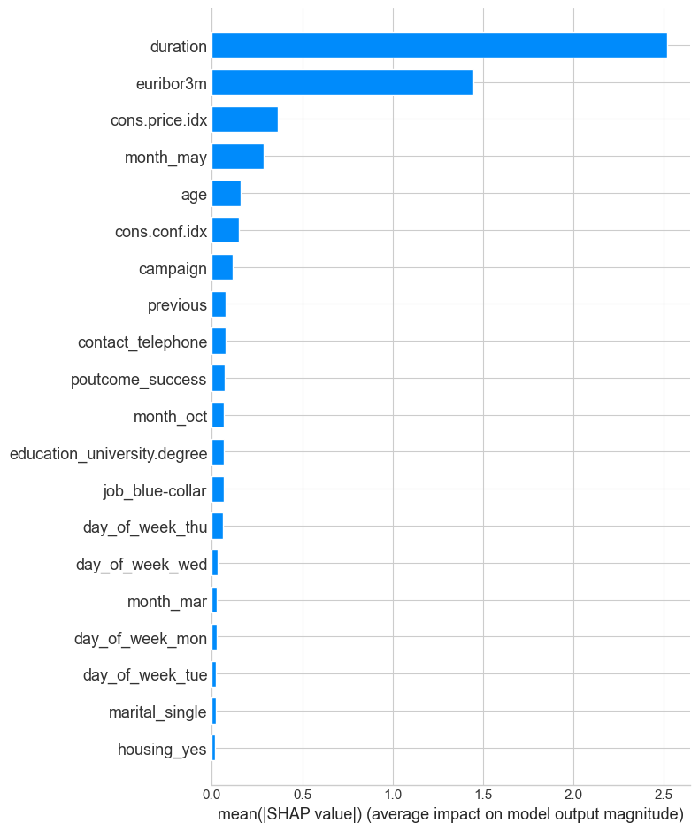

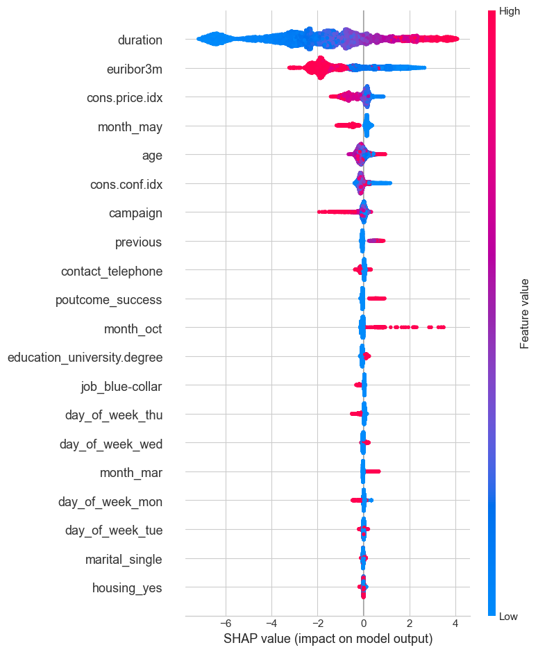

```python
# SHAP summary plots
shap.summary_plot(shap_values_used, X_test_for_shap, plot_type="bar", max_display=20)
shap.summary_plot(shap_values_used, X_test_for_shap, max_display=20)
```

### 3.5 Example of a local SHAP explanation

We can inspect how the model arrived at its prediction for a single customer.

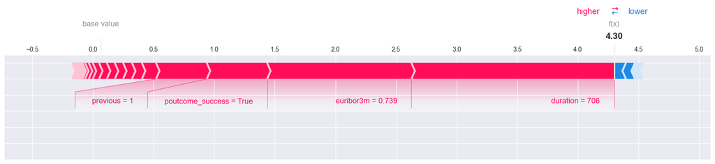

```python
# Select one positive instance if available, otherwise the first test instance
idx_pos = np.where(y_test == 1)[0]
if len(idx_pos) > 0:
    i = idx_pos[0]
else:
    i = 0

instance = X_test_for_shap.iloc[i : i + 1, :]

shap_values_instance = explainer.shap_values(instance)

if isinstance(shap_values_instance, list) and len(shap_values_instance) == 2:
    shap_values_instance_used = shap_values_instance[1]
else:
    shap_values_instance_used = shap_values_instance

shap.force_plot(
    explainer.expected_value if not isinstance(explainer.expected_value, (list, np.ndarray))
    else explainer.expected_value[1],
    shap_values_instance_used,
    instance,
    matplotlib=True,
    show=True
)
```

The force plot here shows how each feature pushes the prediction away from the baseline probability towards either 0 (no deposit) or 1 (deposit) for this specific customer, providing an intuitive, case‑by‑case explanation that can be discussed with business stakeholders or used for auditability.